# Modelling II

## Learning objectives

- Write `R` code to fit a linear model with interaction terms in the explanatory variables
- Interpret estimated effects with reference to confidence intervals from linear regression models. Specifically the interpretation of 1) main effects in a model with an interaction and 2) the effect of one variable when others are included in the model
- Explain why you may want to include interaction effects in a linear model
- Describe the differences between the operators : and * in an `R` model-fitting formula
- Critique the fitted model

## The P\(\overline{\text{a}}\)ua dataset

The P\(\overline{\text{a}}\)ua dataset contains the following variables

- Age of P\(\overline{\text{a}}\)ua in years (calculated from counting rings in the cone)
- Length of P\(\overline{\text{a}}\)ua shell in centimeters
- Species of P\(\overline{\text{a}}\)ua: *Haliotis iris* (typically found in NZ) and *Haliotis australis* (less commonly found in NZ)

## Simple linear regression

\[Y_i = \beta_0 + \beta_1x_i + \epsilon_i\] \[\epsilon_i \sim \text{Normal}(0,\sigma^2)\] Here for observation \(i\)

- \(Y_i\) is the value of the response (in our case Age of P\(\overline{\text{a}}\)ua)
- \(x_i\) is the value of the explanatory variable (Length of P\(\overline{\text{a}}\)ua shell)
- \(\epsilon_i\) is the error term: the difference between \(Y_i\) and its expected value

## Multiple linear regression

\[Y_i = \beta_0 + \beta_1x_i + \beta_2 z_i + \epsilon_i\] \[\epsilon_i \sim \text{Normal}(0,\sigma^2)\] Here for observation \(i\)

- \(Y_i\) is the value of the response (Age of P\(\overline{\text{a}}\)ua)
- \(x_i\) is the value of one explanatory variable (e.g., Length of P\(\overline{\text{a}}\)ua shell)
- \(z_i\) is the value of another explanatory variable (e.g., Species of P\(\overline{\text{a}}\)ua)
- \(\epsilon_i\) is the error term: the difference between \(Y_i\) and its expected value

## Fitted model

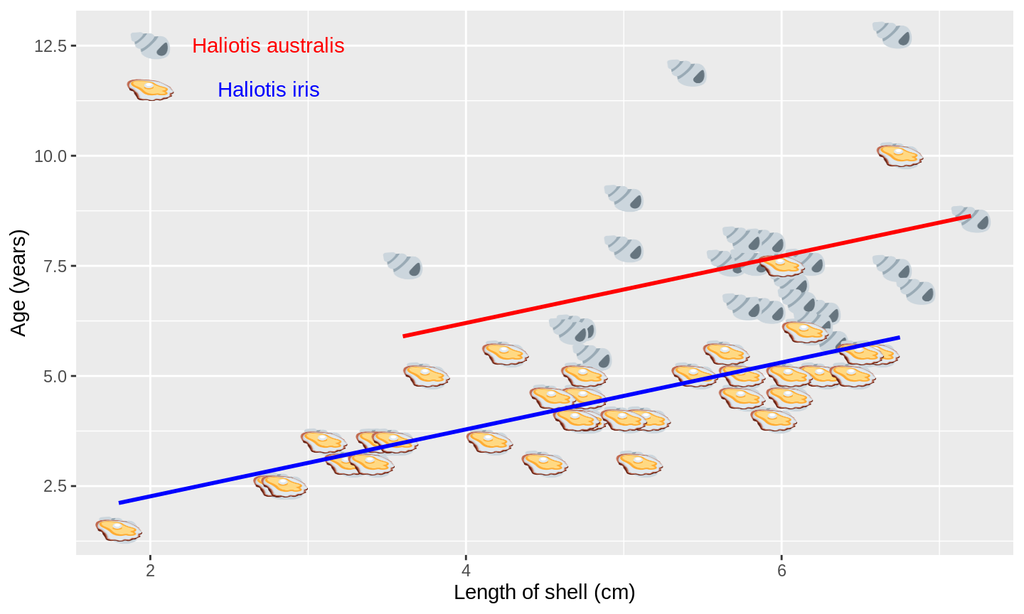

But, what if the lines aren't parallel?

## Interactions

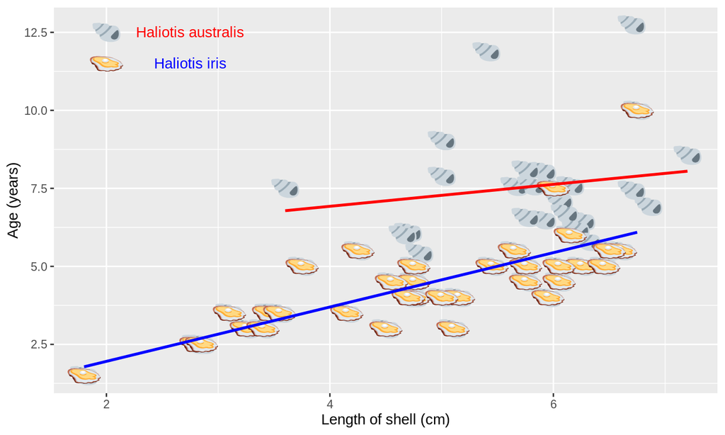

https://b.socrative.com/login/student/ Room Name: BIOSCI220